# Risk Factor Analysis

## Outcome Variable

**Outcome Variable:** haz

## Predictor Variables

**Intervention Variable:** rain_quartile

**Adjustment Set:**

unadjusted

## Stratifying Variables

The analysis was stratified on these variable(s):

- studyid
- country
- agecat

## Data Summary

| studyid | country | agecat | rain_quartile | n_cell | n | outcome_variable |
| --- | --- | --- | --- | --- | --- | --- |
| CMC-V-BCS-2002 | India | Birth | 1 | 18 | 92 | haz |
| CMC-V-BCS-2002 | India | Birth | 2 | 25 | 92 | haz |
| CMC-V-BCS-2002 | India | Birth | 3 | 30 | 92 | haz |
| CMC-V-BCS-2002 | India | Birth | 4 | 19 | 92 | haz |
| CMC-V-BCS-2002 | India | 6 months | 1 | 101 | 369 | haz |
| CMC-V-BCS-2002 | India | 6 months | 2 | 111 | 369 | haz |
| CMC-V-BCS-2002 | India | 6 months | 3 | 97 | 369 | haz |
| CMC-V-BCS-2002 | India | 6 months | 4 | 60 | 369 | haz |
| CMC-V-BCS-2002 | India | 24 months | 1 | 87 | 333 | haz |
| CMC-V-BCS-2002 | India | 24 months | 2 | 90 | 333 | haz |
| CMC-V-BCS-2002 | India | 24 months | 3 | 94 | 333 | haz |
| CMC-V-BCS-2002 | India | 24 months | 4 | 62 | 333 | haz |
| CMIN | Bangladesh | Birth | 1 | 7 | 26 | haz |
| CMIN | Bangladesh | Birth | 2 | 6 | 26 | haz |
| CMIN | Bangladesh | Birth | 3 | 6 | 26 | haz |
| CMIN | Bangladesh | Birth | 4 | 7 | 26 | haz |
| CMIN | Bangladesh | 6 months | 1 | 50 | 243 | haz |
| CMIN | Bangladesh | 6 months | 2 | 62 | 243 | haz |
| CMIN | Bangladesh | 6 months | 3 | 71 | 243 | haz |
| CMIN | Bangladesh | 6 months | 4 | 60 | 243 | haz |
| CMIN | Bangladesh | 24 months | 1 | 72 | 224 | haz |
| CMIN | Bangladesh | 24 months | 2 | 64 | 224 | haz |
| CMIN | Bangladesh | 24 months | 3 | 52 | 224 | haz |
| CMIN | Bangladesh | 24 months | 4 | 36 | 224 | haz |
| CONTENT | Peru | Birth | 1 | 0 | 2 | haz |
| CONTENT | Peru | Birth | 2 | 2 | 2 | haz |
| CONTENT | Peru | Birth | 3 | 0 | 2 | haz |
| CONTENT | Peru | Birth | 4 | 0 | 2 | haz |
| CONTENT | Peru | 6 months | 1 | 62 | 215 | haz |
| CONTENT | Peru | 6 months | 2 | 32 | 215 | haz |

[output cut: 238 more lines]

The following strata were considered:

- studyid: CMC-V-BCS-2002, country: India, agecat: 24 months
- studyid: CMC-V-BCS-2002, country: India, agecat: 6 months
- studyid: CMC-V-BCS-2002, country: India, agecat: Birth
- studyid: CMIN, country: Bangladesh, agecat: 24 months
- studyid: CMIN, country: Bangladesh, agecat: 6 months
- studyid: CMIN, country: Bangladesh, agecat: Birth
- studyid: CONTENT, country: Peru, agecat: 24 months
- studyid: CONTENT, country: Peru, agecat: 6 months
- studyid: CONTENT, country: Peru, agecat: Birth
- studyid: EE, country: Pakistan, agecat: 24 months
- studyid: EE, country: Pakistan, agecat: 6 months
- studyid: EE, country: Pakistan, agecat: Birth
- studyid: GMS-Nepal, country: Nepal, agecat: 24 months
- studyid: GMS-Nepal, country: Nepal, agecat: 6 months
- studyid: GMS-Nepal, country: Nepal, agecat: Birth
- studyid: Guatemala BSC, country: Guatemala, agecat: 6 months
- studyid: IRC, country: India, agecat: 24 months
- studyid: IRC, country: India, agecat: 6 months
- studyid: IRC, country: India, agecat: Birth
- studyid: JiVitA-3, country: Bangladesh, agecat: 24 months
- studyid: JiVitA-3, country: Bangladesh, agecat: 6 months
- studyid: JiVitA-3, country: Bangladesh, agecat: Birth
- studyid: JiVitA-4, country: Bangladesh, agecat: 24 months
- studyid: JiVitA-4, country: Bangladesh, agecat: 6 months
- studyid: JiVitA-4, country: Bangladesh, agecat: Birth
- studyid: Keneba, country: Gambia, agecat: 24 months
- studyid: Keneba, country: Gambia, agecat: 6 months
- studyid: Keneba, country: Gambia, agecat: Birth
- studyid: LCNI-5, country: Malawi, agecat: 24 months
- studyid: LCNI-5, country: Malawi, agecat: 6 months
- studyid: MAL-ED, country: Bangladesh, agecat: 24 months
- studyid: MAL-ED, country: Bangladesh, agecat: 6 months
- studyid: MAL-ED, country: Bangladesh, agecat: Birth
- studyid: MAL-ED, country: Brazil, agecat: 24 months
- studyid: MAL-ED, country: Brazil, agecat: 6 months
- studyid: MAL-ED, country: Brazil, agecat: Birth
- studyid: MAL-ED, country: India, agecat: 24 months
- studyid: MAL-ED, country: India, agecat: 6 months
- studyid: MAL-ED, country: India, agecat: Birth
- studyid: MAL-ED, country: Nepal, agecat: 24 months
- studyid: MAL-ED, country: Nepal, agecat: 6 months
- studyid: MAL-ED, country: Nepal, agecat: Birth
- studyid: MAL-ED, country: Peru, agecat: 24 months
- studyid: MAL-ED, country: Peru, agecat: 6 months
- studyid: MAL-ED, country: Peru, agecat: Birth
- studyid: MAL-ED, country: South Africa, agecat: 24 months
- studyid: MAL-ED, country: South Africa, agecat: 6 months
- studyid: MAL-ED, country: South Africa, agecat: Birth
- studyid: MAL-ED, country: Tanzania, agecat: 24 months
- studyid: MAL-ED, country: Tanzania, agecat: 6 months
- studyid: MAL-ED, country: Tanzania, agecat: Birth
- studyid: PROBIT, country: Belarus, agecat: 24 months
- studyid: PROBIT, country: Belarus, agecat: 6 months
- studyid: PROBIT, country: Belarus, agecat: Birth
- studyid: PROVIDE, country: Bangladesh, agecat: 24 months
- studyid: PROVIDE, country: Bangladesh, agecat: 6 months
- studyid: PROVIDE, country: Bangladesh, agecat: Birth
- studyid: ResPak, country: Pakistan, agecat: 6 months
- studyid: ResPak, country: Pakistan, agecat: Birth
- studyid: SAS-CompFeed, country: India, agecat: 6 months
- studyid: SAS-CompFeed, country: India, agecat: Birth
- studyid: SAS-FoodSuppl, country: India, agecat: 6 months
- studyid: TanzaniaChild2, country: Tanzania, agecat: 24 months
- studyid: TanzaniaChild2, country: Tanzania, agecat: 6 months
- studyid: ZVITAMBO, country: Zimbabwe, agecat: 24 months
- studyid: ZVITAMBO, country: Zimbabwe, agecat: 6 months
- studyid: ZVITAMBO, country: Zimbabwe, agecat: Birth

### Dropped Strata

Some strata were dropped due to rare outcomes:

- studyid: CONTENT, country: Peru, agecat: Birth
- studyid: EE, country: Pakistan, agecat: Birth
- studyid: EE, country: Pakistan, agecat: 6 months
- studyid: EE, country: Pakistan, agecat: 24 months
- studyid: GMS-Nepal, country: Nepal, agecat: Birth
- studyid: GMS-Nepal, country: Nepal, agecat: 6 months
- studyid: GMS-Nepal, country: Nepal, agecat: 24 months
- studyid: JiVitA-3, country: Bangladesh, agecat: 24 months
- studyid: PROVIDE, country: Bangladesh, agecat: 24 months
- studyid: ResPak, country: Pakistan, agecat: Birth
- studyid: TanzaniaChild2, country: Tanzania, agecat: 24 months

## Methods Detail

We’re interested in the causal parameters $E[Y_a]$ for all values of $a \in \mathcal{A}$. These parameters represent the mean outcome if, possibly contrary to fact, we intervened to set all units to have $A=a$. Under the randomization and positivity assumptions, these are identified by the statistical parameters $\psi_a=E_W[E_{Y|A,W}(Y|A=a,W)]$. In addition, we’re interested in the mean of $Y$, $E[Y]$ under no intervention (the observed mean). We will estimate these parameters by using SuperLearner to fit the relevant likelihood factors – $E_{Y|A,W}(Y|A=a,W)$ and $p(A=a|W)$, and then updating our likelihood fit using a joint TMLE.

For unadjusted analyses ($W=\{\}$), initial likelihoods were estimated using Lrnr_glm to estimate the simple $E(Y|A)$ and Lrnr_mean to estimate $p(A)$. For adjusted analyses, a small library containing Lrnr_glmnet, Lrnr_xgboost, and Lrnr_mean was used.

Having estimated these parameters, we will then use the delta method to estimate relative risks and attributable risks relative to a prespecified baseline level of $A$.

# Results Detail

## Results Plots

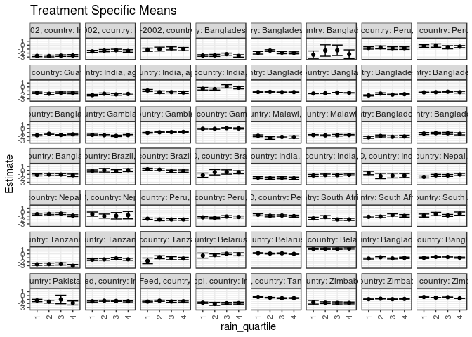

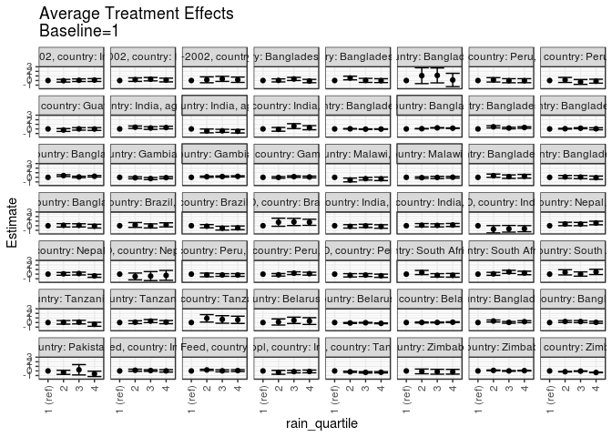

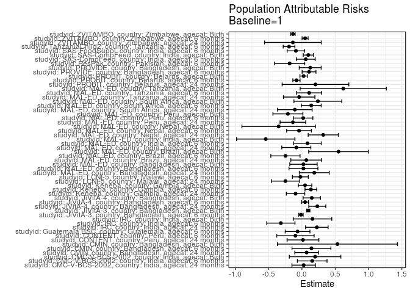

## Results Table

### Parameter: TSM

| studyid | country | agecat | intervention_level | baseline_level | estimate | ci_lower | ci_upper |
| --- | --- | --- | --- | --- | --- | --- | --- |
| CMC-V-BCS-2002 | India | Birth | 1 | NA | -1.1586111 | -1.5695857 | -0.7476366 |
| CMC-V-BCS-2002 | India | Birth | 2 | NA | -0.9960000 | -1.4894453 | -0.5025547 |
| CMC-V-BCS-2002 | India | Birth | 3 | NA | -0.7980000 | -1.1673928 | -0.4286072 |
| CMC-V-BCS-2002 | India | Birth | 4 | NA | -0.9860526 | -1.3972198 | -0.5748855 |
| CMC-V-BCS-2002 | India | 6 months | 1 | NA | -1.5773762 | -1.8337127 | -1.3210398 |
| CMC-V-BCS-2002 | India | 6 months | 2 | NA | -1.3823423 | -1.6684306 | -1.0962540 |
| CMC-V-BCS-2002 | India | 6 months | 3 | NA | -1.2860309 | -1.5498132 | -1.0222486 |
| CMC-V-BCS-2002 | India | 6 months | 4 | NA | -1.4625556 | -1.7796120 | -1.1454992 |
| CMC-V-BCS-2002 | India | 24 months | 1 | NA | -2.7185057 | -2.9225781 | -2.5144334 |
| CMC-V-BCS-2002 | India | 24 months | 2 | NA | -2.7580556 | -2.9716638 | -2.5444473 |
| CMC-V-BCS-2002 | India | 24 months | 3 | NA | -2.6550000 | -2.8483400 | -2.4616600 |
| CMC-V-BCS-2002 | India | 24 months | 4 | NA | -2.6190323 | -2.8535167 | -2.3845478 |
| CMIN | Bangladesh | Birth | 1 | NA | -2.4142857 | -3.3615713 | -1.4670002 |
| CMIN | Bangladesh | Birth | 2 | NA | -1.3566667 | -2.8032226 | 0.0898892 |
| CMIN | Bangladesh | Birth | 3 | NA | -1.2983333 | -2.6238587 | 0.0271920 |
| CMIN | Bangladesh | Birth | 4 | NA | -2.2971429 | -3.3977700 | -1.1965157 |
| CMIN | Bangladesh | 6 months | 1 | NA | -1.9272333 | -2.2628041 | -1.5916625 |
| CMIN | Bangladesh | 6 months | 2 | NA | -1.3762903 | -1.5882531 | -1.1643276 |
| CMIN | Bangladesh | 6 months | 3 | NA | -1.8977700 | -2.1727001 | -1.6228398 |
| CMIN | Bangladesh | 6 months | 4 | NA | -1.9530833 | -2.2075111 | -1.6986556 |
| CMIN | Bangladesh | 24 months | 1 | NA | -2.6269444 | -2.8317317 | -2.4221572 |
| CMIN | Bangladesh | 24 months | 2 | NA | -2.5953125 | -2.8554854 | -2.3351396 |
| CMIN | Bangladesh | 24 months | 3 | NA | -2.2843269 | -2.5576953 | -2.0109585 |
| CMIN | Bangladesh | 24 months | 4 | NA | -2.7388889 | -3.0385266 | -2.4392511 |
| CONTENT | Peru | 6 months | 1 | NA | -0.2164516 | -0.5554492 | 0.1225460 |
| CONTENT | Peru | 6 months | 2 | NA | -0.0920469 | -0.5202554 | 0.3361617 |
| CONTENT | Peru | 6 months | 3 | NA | -0.5241553 | -0.9278955 | -0.1204151 |
| CONTENT | Peru | 6 months | 4 | NA | -0.3644784 | -0.6308191 | -0.0981376 |
| CONTENT | Peru | 24 months | 1 | NA | -0.7114545 | -1.0009618 | -0.4219473 |
| CONTENT | Peru | 24 months | 2 | NA | -0.5611429 | -0.9357337 | -0.1865520 |

[output cut: 194 more lines]

### Parameter: E(Y)

| studyid | country | agecat | intervention_level | baseline_level | estimate | ci_lower | ci_upper |
| --- | --- | --- | --- | --- | --- | --- | --- |
| CMC-V-BCS-2002 | India | Birth | NA | NA | -0.9611957 | -1.1776967 | -0.7446946 |
| CMC-V-BCS-2002 | India | 6 months | NA | NA | -1.4234508 | -1.5645974 | -1.2823042 |
| CMC-V-BCS-2002 | India | 24 months | NA | NA | -2.6927477 | -2.7980658 | -2.5874297 |
| CMIN | Bangladesh | Birth | NA | NA | -1.8811538 | -2.5124807 | -1.2498270 |
| CMIN | Bangladesh | 6 months | NA | NA | -1.7844376 | -1.9222926 | -1.6465825 |
| CMIN | Bangladesh | 24 months | NA | NA | -2.5563616 | -2.6853113 | -2.4274119 |
| CONTENT | Peru | 6 months | NA | NA | -0.3139217 | -0.4868486 | -0.1409948 |
| CONTENT | Peru | 24 months | NA | NA | -0.6962195 | -0.8674103 | -0.5250287 |
| Guatemala BSC | Guatemala | 6 months | NA | NA | -1.5619008 | -1.6727702 | -1.4510313 |
| IRC | India | Birth | NA | NA | -0.3080412 | -0.4687931 | -0.1472894 |
| IRC | India | 6 months | NA | NA | -1.2344062 | -1.3658524 | -1.1029600 |
| IRC | India | 24 months | NA | NA | -1.8787176 | -1.9805661 | -1.7768691 |
| JiVitA-3 | Bangladesh | Birth | NA | NA | -1.5894148 | -1.6086362 | -1.5701935 |
| JiVitA-3 | Bangladesh | 6 months | NA | NA | -1.3130932 | -1.3362359 | -1.2899505 |
| JiVitA-4 | Bangladesh | Birth | NA | NA | -1.5232908 | -1.5723277 | -1.4742539 |
| JiVitA-4 | Bangladesh | 6 months | NA | NA | -1.3447940 | -1.3820261 | -1.3075620 |
| JiVitA-4 | Bangladesh | 24 months | NA | NA | -1.9327943 | -1.9977741 | -1.8678145 |
| Keneba | Gambia | Birth | NA | NA | 0.0308036 | -0.0328378 | 0.0944451 |
| Keneba | Gambia | 6 months | NA | NA | -0.9036375 | -0.9508087 | -0.8564663 |
| Keneba | Gambia | 24 months | NA | NA | -1.6554946 | -1.7360989 | -1.5748903 |
| LCNI-5 | Malawi | 6 months | NA | NA | -1.6601907 | -1.7297701 | -1.5906113 |
| LCNI-5 | Malawi | 24 months | NA | NA | -2.0459112 | -2.1718307 | -1.9199918 |
| MAL-ED | Bangladesh | Birth | NA | NA | -1.1180952 | -1.2525408 | -0.9836496 |
| MAL-ED | Bangladesh | 6 months | NA | NA | -1.2049931 | -1.3222136 | -1.0877726 |
| MAL-ED | Bangladesh | 24 months | NA | NA | -2.0203209 | -2.1567304 | -1.8839113 |
| MAL-ED | Brazil | Birth | NA | NA | -0.6760000 | -0.9521457 | -0.3998543 |
| MAL-ED | Brazil | 6 months | NA | NA | 0.0475758 | -0.0963508 | 0.1915023 |
| MAL-ED | Brazil | 24 months | NA | NA | -0.0663473 | -0.2413659 | 0.1086713 |
| MAL-ED | India | Birth | NA | NA | -1.2036170 | -1.4976814 | -0.9095527 |
| MAL-ED | India | 6 months | NA | NA | -1.2115254 | -1.3298727 | -1.0931782 |
| MAL-ED | India | 24 months | NA | NA | -1.9337871 | -2.0691373 | -1.7984370 |
| MAL-ED | Nepal | Birth | NA | NA | -0.8533333 | -1.2104864 | -0.4961803 |
| MAL-ED | Nepal | 6 months | NA | NA | -0.5615819 | -0.6741832 | -0.4489807 |
| MAL-ED | Nepal | 24 months | NA | NA | -1.3339250 | -1.4668700 | -1.2009800 |
| MAL-ED | Peru | Birth | NA | NA | -0.8827897 | -1.0001058 | -0.7654736 |
| MAL-ED | Peru | 6 months | NA | NA | -1.3236661 | -1.4316775 | -1.2156546 |
| MAL-ED | Peru | 24 months | NA | NA | -1.8184925 | -1.9407024 | -1.6962825 |
| MAL-ED | South Africa | Birth | NA | NA | -0.6317073 | -0.8249555 | -0.4384591 |
| MAL-ED | South Africa | 6 months | NA | NA | -1.0633202 | -1.1909180 | -0.9357224 |
| MAL-ED | South Africa | 24 months | NA | NA | -1.7086453 | -1.8487775 | -1.5685131 |
| MAL-ED | Tanzania | Birth | NA | NA | -1.1556000 | -1.3655361 | -0.9456639 |
| MAL-ED | Tanzania | 6 months | NA | NA | -1.3687449 | -1.4907629 | -1.2467270 |
| MAL-ED | Tanzania | 24 months | NA | NA | -2.6979508 | -2.8450645 | -2.5508372 |
| PROBIT | Belarus | Birth | NA | NA | 1.3269446 | 1.1683850 | 1.4855041 |
| PROBIT | Belarus | 6 months | NA | NA | 0.1068536 | 0.0120998 | 0.2016074 |
| PROBIT | Belarus | 24 months | NA | NA | -0.2282149 | -0.4620519 | 0.0056221 |
| PROVIDE | Bangladesh | Birth | NA | NA | -0.8851020 | -0.9601332 | -0.8100709 |
| PROVIDE | Bangladesh | 6 months | NA | NA | -1.0916915 | -1.1661176 | -1.0172654 |
| ResPak | Pakistan | 6 months | NA | NA | -1.4314086 | -1.6374838 | -1.2253335 |
| SAS-CompFeed | India | Birth | NA | NA | -1.4314217 | -1.5099245 | -1.3529189 |
| SAS-CompFeed | India | 6 months | NA | NA | -1.4018563 | -1.4810585 | -1.3226541 |
| SAS-FoodSuppl | India | 6 months | NA | NA | -1.8986842 | -2.0118892 | -1.7854792 |
| TanzaniaChild2 | Tanzania | 6 months | NA | NA | -0.5434389 | -0.5924056 | -0.4944722 |
| ZVITAMBO | Zimbabwe | Birth | NA | NA | -0.5002724 | -0.5208163 | -0.4797285 |
| ZVITAMBO | Zimbabwe | 6 months | NA | NA | -0.8679450 | -0.8935071 | -0.8423828 |
| ZVITAMBO | Zimbabwe | 24 months | NA | NA | -1.8369146 | -1.9746779 | -1.6991513 |

### Parameter: ATE

| studyid | country | agecat | intervention_level | baseline_level | estimate | ci_lower | ci_upper |
| --- | --- | --- | --- | --- | --- | --- | --- |
| CMC-V-BCS-2002 | India | Birth | 1 | 1 | 0.0000000 | 0.0000000 | 0.0000000 |
| CMC-V-BCS-2002 | India | Birth | 2 | 1 | 0.1626111 | -0.4795636 | 0.8047858 |
| CMC-V-BCS-2002 | India | Birth | 3 | 1 | 0.3606111 | -0.1919747 | 0.9131970 |
| CMC-V-BCS-2002 | India | Birth | 4 | 1 | 0.1725585 | -0.4087835 | 0.7539005 |
| CMC-V-BCS-2002 | India | 6 months | 1 | 1 | 0.0000000 | 0.0000000 | 0.0000000 |
| CMC-V-BCS-2002 | India | 6 months | 2 | 1 | 0.1950339 | -0.1890949 | 0.5791627 |
| CMC-V-BCS-2002 | India | 6 months | 3 | 1 | 0.2913453 | -0.0764719 | 0.6591625 |
| CMC-V-BCS-2002 | India | 6 months | 4 | 1 | 0.1148207 | -0.2928963 | 0.5225377 |
| CMC-V-BCS-2002 | India | 24 months | 1 | 1 | 0.0000000 | 0.0000000 | 0.0000000 |
| CMC-V-BCS-2002 | India | 24 months | 2 | 1 | -0.0395498 | -0.3349715 | 0.2558719 |
| CMC-V-BCS-2002 | India | 24 months | 3 | 1 | 0.0635057 | -0.2176097 | 0.3446211 |
| CMC-V-BCS-2002 | India | 24 months | 4 | 1 | 0.0994735 | -0.2113777 | 0.4103247 |
| CMIN | Bangladesh | Birth | 1 | 1 | 0.0000000 | 0.0000000 | 0.0000000 |
| CMIN | Bangladesh | Birth | 2 | 1 | 1.0576190 | -0.6715061 | 2.7867442 |
| CMIN | Bangladesh | Birth | 3 | 1 | 1.1159524 | -0.5132705 | 2.7451753 |
| CMIN | Bangladesh | Birth | 4 | 1 | 0.1171429 | -1.3350038 | 1.5692895 |
| CMIN | Bangladesh | 6 months | 1 | 1 | 0.0000000 | 0.0000000 | 0.0000000 |
| CMIN | Bangladesh | 6 months | 2 | 1 | 0.5509430 | 0.1540350 | 0.9478510 |
| CMIN | Bangladesh | 6 months | 3 | 1 | 0.0294634 | -0.4043504 | 0.4632771 |
| CMIN | Bangladesh | 6 months | 4 | 1 | -0.0258500 | -0.4469690 | 0.3952690 |
| CMIN | Bangladesh | 24 months | 1 | 1 | 0.0000000 | 0.0000000 | 0.0000000 |
| CMIN | Bangladesh | 24 months | 2 | 1 | 0.0316319 | -0.2994688 | 0.3627327 |
| CMIN | Bangladesh | 24 months | 3 | 1 | 0.3426175 | 0.0010504 | 0.6841846 |
| CMIN | Bangladesh | 24 months | 4 | 1 | -0.1119444 | -0.4748777 | 0.2509889 |
| CONTENT | Peru | 6 months | 1 | 1 | 0.0000000 | 0.0000000 | 0.0000000 |
| CONTENT | Peru | 6 months | 2 | 1 | 0.1244047 | -0.4217472 | 0.6705567 |
| CONTENT | Peru | 6 months | 3 | 1 | -0.3077037 | -0.8348902 | 0.2194828 |
| CONTENT | Peru | 6 months | 4 | 1 | -0.1480267 | -0.5791379 | 0.2830844 |
| CONTENT | Peru | 24 months | 1 | 1 | 0.0000000 | 0.0000000 | 0.0000000 |
| CONTENT | Peru | 24 months | 2 | 1 | 0.1503117 | -0.3231149 | 0.6237383 |

[output cut: 194 more lines]

### Parameter: PAR

| studyid | country | agecat | intervention_level | baseline_level | estimate | ci_lower | ci_upper |
| --- | --- | --- | --- | --- | --- | --- | --- |
| CMC-V-BCS-2002 | India | Birth | 1 | NA | 0.1974155 | -0.1894714 | 0.5843023 |
| CMC-V-BCS-2002 | India | 6 months | 1 | NA | 0.1539255 | -0.0689205 | 0.3767714 |
| CMC-V-BCS-2002 | India | 24 months | 1 | NA | 0.0257580 | -0.1502440 | 0.2017600 |
| CMIN | Bangladesh | Birth | 1 | NA | 0.5331319 | -0.3683864 | 1.4346501 |
| CMIN | Bangladesh | 6 months | 1 | NA | 0.1427957 | -0.1492165 | 0.4348080 |
| CMIN | Bangladesh | 24 months | 1 | NA | 0.0705828 | -0.1071974 | 0.2483631 |
| CONTENT | Peru | 6 months | 1 | NA | -0.0974701 | -0.3777271 | 0.1827870 |
| CONTENT | Peru | 24 months | 1 | NA | 0.0152350 | -0.2233100 | 0.2537800 |
| Guatemala BSC | Guatemala | 6 months | 1 | NA | -0.0656508 | -0.2514775 | 0.1201760 |
| IRC | India | Birth | 1 | NA | 0.1585867 | -0.1309468 | 0.4481202 |
| IRC | India | 6 months | 1 | NA | -0.3168152 | -0.5290001 | -0.1046303 |
| IRC | India | 24 months | 1 | NA | 0.2236387 | 0.0543040 | 0.3929735 |
| JiVitA-3 | Bangladesh | Birth | 1 | NA | 0.0950467 | 0.0708742 | 0.1192192 |
| JiVitA-3 | Bangladesh | 6 months | 1 | NA | -0.0146211 | -0.0475466 | 0.0183043 |
| JiVitA-4 | Bangladesh | Birth | 1 | NA | 0.1473398 | 0.0167722 | 0.2779074 |
| JiVitA-4 | Bangladesh | 6 months | 1 | NA | 0.0472277 | -0.0043977 | 0.0988532 |
| JiVitA-4 | Bangladesh | 24 months | 1 | NA | 0.2305715 | 0.1028980 | 0.3582450 |
| Keneba | Gambia | Birth | 1 | NA | 0.0468527 | -0.0546403 | 0.1483457 |
| Keneba | Gambia | 6 months | 1 | NA | 0.1343147 | 0.0459078 | 0.2227216 |
| Keneba | Gambia | 24 months | 1 | NA | -0.0958878 | -0.2342435 | 0.0424678 |
| LCNI-5 | Malawi | 6 months | 1 | NA | -0.0232789 | -0.1425598 | 0.0960019 |
| LCNI-5 | Malawi | 24 months | 1 | NA | -0.2488524 | -0.4577739 | -0.0399309 |
| MAL-ED | Bangladesh | Birth | 1 | NA | 0.0227871 | -0.1828251 | 0.2283993 |
| MAL-ED | Bangladesh | 6 months | 1 | NA | 0.0224009 | -0.1941695 | 0.2389712 |
| MAL-ED | Bangladesh | 24 months | 1 | NA | 0.1849853 | -0.0398442 | 0.4098147 |
| MAL-ED | Brazil | Birth | 1 | NA | 0.5487368 | 0.1010558 | 0.9964179 |
| MAL-ED | Brazil | 6 months | 1 | NA | -0.2479711 | -0.4676406 | -0.0283016 |
| MAL-ED | Brazil | 24 months | 1 | NA | 0.0649490 | -0.1671557 | 0.2970537 |
| MAL-ED | India | Birth | 1 | NA | -0.5436170 | -0.9818637 | -0.1053703 |
| MAL-ED | India | 6 months | 1 | NA | 0.0824392 | -0.1246957 | 0.2895742 |
| MAL-ED | India | 24 months | 1 | NA | -0.0846695 | -0.3030335 | 0.1336945 |
| MAL-ED | Nepal | Birth | 1 | NA | -0.3493333 | -0.9012361 | 0.2025694 |
| MAL-ED | Nepal | 6 months | 1 | NA | -0.0437486 | -0.2294313 | 0.1419341 |
| MAL-ED | Nepal | 24 months | 1 | NA | 0.3198985 | 0.0933630 | 0.5464341 |
| MAL-ED | Peru | Birth | 1 | NA | -0.2107489 | -0.4355980 | 0.0141002 |
| MAL-ED | Peru | 6 months | 1 | NA | 0.0188513 | -0.1260656 | 0.1637682 |
| MAL-ED | Peru | 24 months | 1 | NA | -0.1359925 | -0.3286521 | 0.0566672 |
| MAL-ED | South Africa | Birth | 1 | NA | 0.2390927 | -0.1202025 | 0.5983878 |
| MAL-ED | South Africa | 6 months | 1 | NA | 0.1395886 | -0.0097579 | 0.2889351 |
| MAL-ED | South Africa | 24 months | 1 | NA | -0.1067564 | -0.3662971 | 0.1527843 |
| MAL-ED | Tanzania | Birth | 1 | NA | 0.6199556 | -0.0270337 | 1.2669448 |
| MAL-ED | Tanzania | 6 months | 1 | NA | 0.1078748 | -0.0806404 | 0.2963899 |
| MAL-ED | Tanzania | 24 months | 1 | NA | -0.0417806 | -0.2780482 | 0.1944870 |
| PROBIT | Belarus | Birth | 1 | NA | 0.0250715 | -0.0302074 | 0.0803505 |
| PROBIT | Belarus | 6 months | 1 | NA | -0.0825982 | -0.1367876 | -0.0284088 |
| PROBIT | Belarus | 24 months | 1 | NA | 0.2035327 | -0.2975316 | 0.7045970 |
| PROVIDE | Bangladesh | Birth | 1 | NA | 0.1237441 | -0.0409324 | 0.2884206 |
| PROVIDE | Bangladesh | 6 months | 1 | NA | 0.1065312 | 0.0025836 | 0.2104788 |
| ResPak | Pakistan | 6 months | 1 | NA | -0.1846953 | -0.4111162 | 0.0417257 |
| SAS-CompFeed | India | Birth | 1 | NA | 0.0956479 | 0.0192806 | 0.1720151 |
| SAS-CompFeed | India | 6 months | 1 | NA | 0.0570237 | -0.0845663 | 0.1986138 |
| SAS-FoodSuppl | India | 6 months | 1 | NA | -0.0906217 | -0.2223120 | 0.0410686 |
| TanzaniaChild2 | Tanzania | 6 months | 1 | NA | -0.1937942 | -0.2816688 | -0.1059196 |
| ZVITAMBO | Zimbabwe | Birth | 1 | NA | -0.1351988 | -0.1682481 | -0.1021494 |
| ZVITAMBO | Zimbabwe | 6 months | 1 | NA | 0.0474505 | 0.0022591 | 0.0926419 |
| ZVITAMBO | Zimbabwe | 24 months | 1 | NA | -0.1361251 | -0.5617639 | 0.2895137 |